# Loan Default Prediction for Financial Risk Management

Bhavana Kappala

2025-02-01

## 1.Working Dataset

```r
df <- read.csv("https://bhavana-dotcom.github.io/Assignments/Data.csv", header = TRUE, stringsAsFactors = FALSE)


# Function to count missing values in character variables, including empty cells

# Function to count missing values in all variables
count_missing_values <- function(data) {
  data %>%
    mutate(across(where(is.character), ~ na_if(., ""))) %>%
    summarise_all(~ sum(is.na(.))) %>%
    pivot_longer(everything(), names_to = "variable", values_to = "missing_count")
}
# Use the function
missing_values <- count_missing_values(df)
print(missing_values)
```

```
# A tibble: 16 × 2
   variable         missing_count
   <chr>                    <int>
 1 Default                      0
 2 Checking_amount              8
 3 Term                         0
 4 Credit_score                 0
 5 Gender                       0
 6 Marital_status               6
 7 Car_loan                     0
 8 Personal_loan                0
 9 Home_loan                    0
10 Education_loan               0
11 Emp_status                   0
12 Amount                       0
13 Saving_amount                0
14 Emp_duration                 0
15 Age                          0
16 No_of_credit_acc             0
```

## 2. Introduction

This data set is collected to analyze factors influencing loan defaults. It is intended for predictive modeling to assess the risk of default based on various customer attributes. The insights from this data set can aid financial institutions in making informed lending decisions and mitigating risk.The data was gathered from banking records, customer financial details, and loan application histories. The data set includes various financial attributes, demographic details, and loan-related information. It has been processed to ensure consistency and usability for analysis. The data set contains 1,000 records and 16 columns. Total Sample Size: 1,000 records Number of Feature Variables: 15 (excluding the target variable “Default”)

*Itemized List of Feature Variables* -

1. Default (int, target variable) – Indicates whether a customer defaulted on a loan (0 = No, 1 = Yes).
2. Checking_amount (float) – Balance in the customer’s checking account.
3. Term (int) – Loan term in months.
4. Credit_score (int) – Customer’s credit score.
5. Gender (categorical) – Gender of the customer (Male/Female).
6. Marital_status (categorical) – Customer’s marital status (Single, Married, etc.).
7. Car_loan (int, boolean) – Whether the customer has a car loan (0 = No, 1 = Yes).
8. Personal_loan (int, boolean) – Whether the customer has a personal loan.
9. Home_loan (int, boolean) – Whether the customer has a home loan.
10. Education_loan (int, boolean) – Whether the customer has an education loan.
11. Emp_status (categorical) – Employment status (e.g., employed, unemployed).
12. Amount (int) – Loan amount requested.
13. Saving_amount (int) – Savings account balance.
14. Emp_duration (int) – Employment duration in months.
15. Age (int) – Age of the customer.
16. No_of_credit_acc (int) – Number of credits accounts the customer holds.

The main purpose of using this dataset is to develop machine learning models to predict loan defaults, perform risk analysis to identify high-risk customers based on financial and demographic attributes and perform customer profiling to understand borrower characteristics that influence loan repayment behavior.

Problem Statements: Develop a predictive model to assess the likelihood of a customer defaulting on a loan based on their financial history, credit score, and demographic details.

## 3. Distribution of Individual Features

Variables such as Checking amount & Marital Status require additional processing and imputation as there are missing values.

**Implications:** If the missing values are not handled properly, it could bias the analysis and affect machine learning models that require complete data.Ignoring these missing values or applying improper imputation could lead to data leakage or incorrect patterns during model training. + For Checking_amount: If missing values are associated with individuals having no checking account, replacing them with a specific category like “No Account” might improve model interpretability. + For Marital_status: If the missing values are random, imputation using the mode (Most Common Category) would help maintain data consistency. However, if the missing values are systematic, a separate “Unknown” category may be necessary to capture its predictive effect.

**Analytical Actions:** For Checking_amount:Replace missing values with “No Account” if it aligns with domain knowledge. Alternatively, use mode imputation (most common category). For Marital_status:Use mode imputation (Single, Married, or other most frequent value). If missing values have a potential pattern, introduce an “Unknown” category.Exploratory Data Analysis (EDA):Conduct statistical tests (e.g., Chi-square test) to check if missing values correlate with the target variable (Default). Visualize distributions before and after imputation to assess impact.

## 4. Relationship between Features

This section explores relationships between key feature variables in the data set, using appropriate visualizations to identify trends, correlations, and patterns. Understanding these relationships is essential for feature selection, engineering, and model development. We analyze:

The scatter plot illustrates the relationship between Credit Score (x-axis) and Amount (y-axis). Here’s a summary of the observed trends:

Range of Credit Scores: The data spans credit scores approximately from 400 to 1000. Range of Amounts: The amounts vary from around 0 to 2500. Distribution: The data points are concentrated primarily in the middle range of credit scores (600–850) and amounts (500–1500). There is no clear linear correlation; instead, the data shows a diffuse, somewhat circular or elliptical pattern. Outliers: There are outliers present, with some extreme values of amounts (>2000) and some at lower credit scores. Conclusion: The relationship between Credit Score and Amount appears to be weak or nonexistent, as there is no discernible trend or pattern.

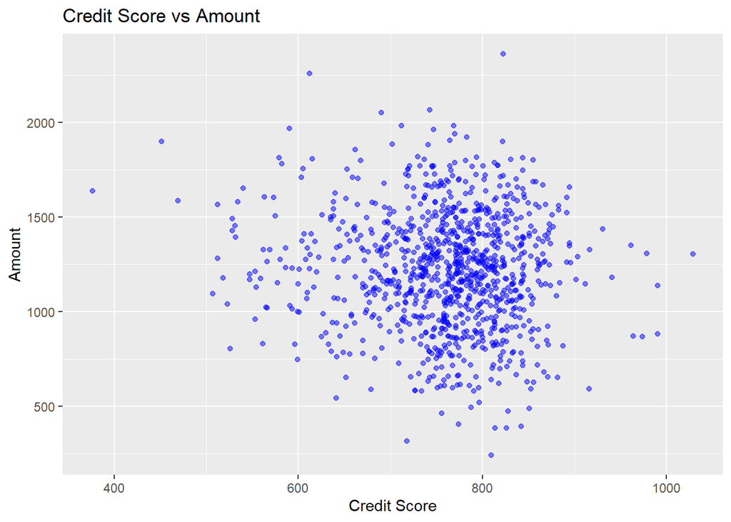

```r
# Scatter plot using ggplot2
ggplot(df, aes(x=Credit_score, y=Amount)) +
  geom_point(color="blue", alpha=0.5) +
  ggtitle("Credit Score vs Amount") +
  xlab("Credit Score") +
  ylab("Amount")
```

```r
df <- read.csv("C:/Users/agaja/Downloads/STA 552/Data.csv", stringsAsFactors = TRUE)

# Converting necessary columns to numeric (as needed)
df$Credit_score <- as.numeric(df$Credit_score)
df$Amount <- as.numeric(df$Amount)
df$Saving_amount <- as.numeric(df$Saving_amount)
df$Emp_duration <- as.numeric(df$Emp_duration)
df$Age <- as.numeric(df$Age)
df$No_of_credit_acc <- as.numeric(df$No_of_credit_acc)
```

**Relationships between two categorical features using grouped bar charts or heatmaps.**

The heatmap in the image visualizes the relationship between Default (presumably a binary variable indicating whether a person defaulted on a loan) and Employment Status (categorical: employed or unemployed). The color gradient represents the frequency of observations in each category, ranging from white (low frequency) to blue (high frequency).

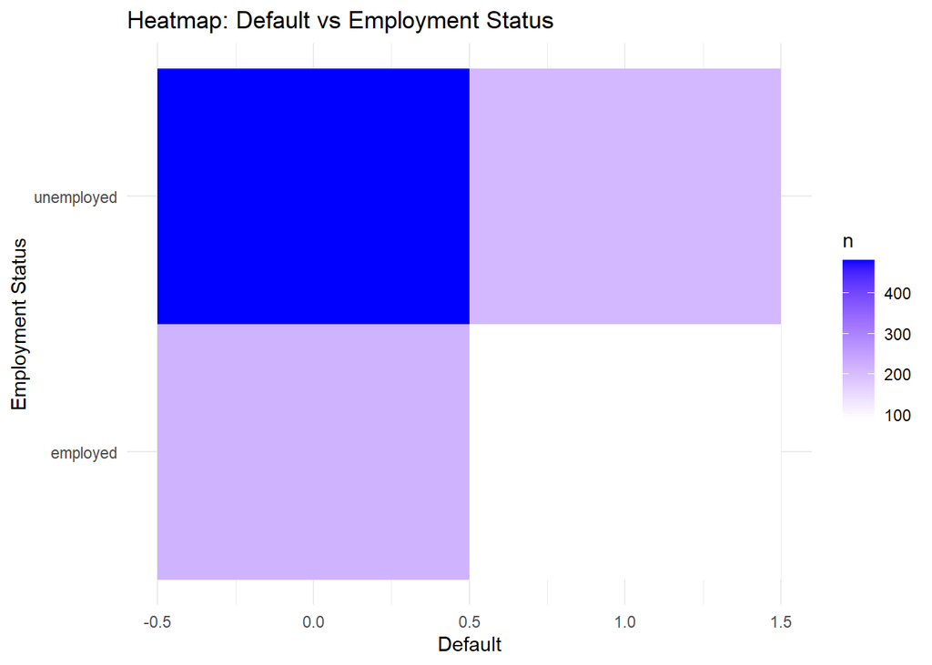

```r
heatmap_data <- df %>%
  count(Default, Emp_status)

# Heatmap: Relationship between Default and Employment Status
ggplot(heatmap_data, aes(x = Default, y = Emp_status, fill = n)) +
  geom_tile() +
  labs(title = "Heatmap: Default vs Employment Status",
       x = "Default", y = "Employment Status") +
  scale_fill_gradient(low = "white", high = "blue") +
  theme_minimal()
```

**Relationships between one numerical and one categorical feature using box plots.** The box plot illustrates the relationship between Marital Status (categorical) and Credit Score (numerical).

Marital Status Categories:

There are at least two categories: “Married” and “Single.” The median credit score is similar for both categories.”Married” individuals appear to have a slightly wider range of credit scores compared to “Single” individuals. Both categories have outliers, with a few credit scores extending below 600 and above 900.The interquartile range (IQR) is slightly larger for “Married” individuals, indicating more variation in their credit scores compared to “Single.” Outliers are observed in both categories, mostly toward the lower end (below 600) and the higher end (above 900).

Conclusion: There doesn’t appear to be a strong difference in the central tendency of credit scores between “Married” and “Single” individuals. However, variability in credit scores is slightly higher for “Married” individuals, with both groups exhibiting similar ranges and outliers.

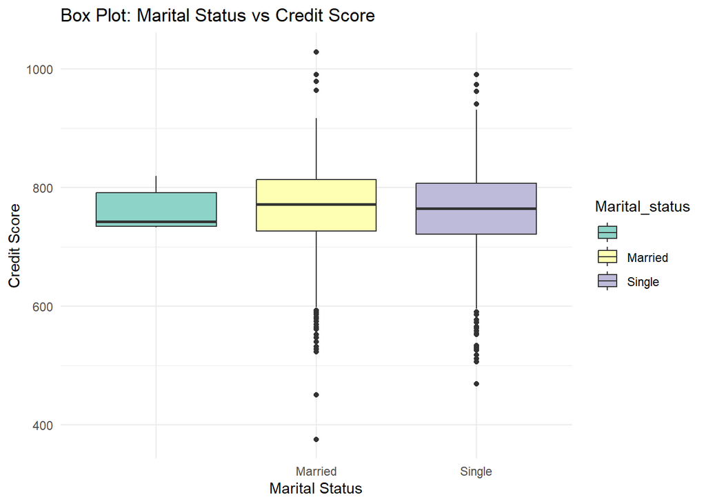

```r
# Box Plot: Relationship between Marital Status (Categorical) and Credit Score (Numerical)
ggplot(df, aes(x = Marital_status, y = Credit_score, fill = Marital_status)) +
  geom_boxplot() +
  labs(title = "Box Plot: Marital Status vs Credit Score",
       x = "Marital Status", y = "Credit Score") +
  theme_minimal() +
  scale_fill_brewer(palette = "Set3")
```